# Regression Models Course Project

Supposing I work for *Motor Trend*, a magazine about the automobile industry. Looking at a data set of a collection of cars, they are interested in exploring the relationship between a set of variables and miles per gallon (MPG) (outcome). They are particularly interested in the following two questions:

- **"Is an automatic or manual transmission better for MPG"**
- **"Quantify the MPG difference between automatic and manual transmissions"**

## **1. Loading Data**

We load the dataset

```r
data(mtcars)
head(mtcars)
```

|  | mpg | cyl | disp | hp | drat | wt | qsec | vs | am | gear | carb |
| --- | --- | --- | --- | --- | --- | --- | --- | --- | --- | --- | --- |
| Mazda RX4 | 21.0 | 6 | 160 | 110 | 3.90 | 2.620 | 16.46 | 0 | 1 | 4 | 4 |
| Mazda RX4 Wag | 21.0 | 6 | 160 | 110 | 3.90 | 2.875 | 17.02 | 0 | 1 | 4 | 4 |
| Datsun 710 | 22.8 | 4 | 108 | 93 | 3.85 | 2.320 | 18.61 | 1 | 1 | 4 | 1 |
| Hornet 4 Drive | 21.4 | 6 | 258 | 110 | 3.08 | 3.215 | 19.44 | 1 | 0 | 3 | 1 |
| Hornet Sportabout | 18.7 | 8 | 360 | 175 | 3.15 | 3.440 | 17.02 | 0 | 0 | 3 | 2 |
| Valiant | 18.1 | 6 | 225 | 105 | 2.76 | 3.460 | 20.22 | 1 | 0 | 3 | 1 |

Motor Trend Car Road Tests

*Description*

The data was extracted from the 1974 Motor Trend US magazine, and comprises fuel consumption and 10 aspects of automobile design and performance for 32 automobiles (1973-74 models).

*Format*

A data frame with 32 observations on 11 (numeric) variables.

| [, 1] | mpg | Miles/(US) gallon |
| --- | --- | --- |
| [, 2] | cyl | Number of cylinders |
| [, 3] | disp | Displacement (cu.in.) |
| [, 4] | hp | Gross horsepower |
| [, 5] | drat | Rear axle ratio |
| [, 6] | wt | Weight (1000 lbs) |
| [, 7] | qsec | 1/4 mile time |
| [, 8] | vs | Engine (0 = V-shaped, 1 = straight) |
| [, 9] | am | Transmission (0 = automatic, 1 = manual) |
| [,10] | gear | Number of forward gears |
| [,11] | carb | Number of carburetors |

For convenience we can convert the variable "am" to a factor and add a more clear classification "Automatic" & "Manual". and we can perform a friefly analysis of both variables

```r
mtcars$am = as.factor(mtcars$am)
levels(mtcars$am) = c("Automatic", "Manual")
summary(mtcars$mpg); summary(mtcars$am)
```

```
   Min. 1st Qu.  Median    Mean 3rd Qu.    Max.
  10.40   15.43   19.20   20.09   22.80   33.90
Automatic    Manual
       19        13
```

# **2.EDA**

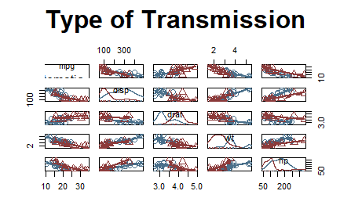

```r
scatterplotMatrix(~mpg+disp+drat+wt+hp|am, data=mtcars, col = c("skyblue4", "indianred4"), main="Type of Transmission", cex.labels= 1,cex.main=2, cex=1.5)
```

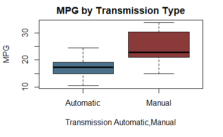

```r
boxplot(mpg~am,data = mtcars,xlab = "Transmission Automatic,Manual", ylab = "MPG", main="MPG by Transmission Type", col=c("skyblue4", "indianred4"))
```